# Midterm

Joseph W. Vera

2022-03-15

# Midterm (Due Sunday 2/13/2022 at 11:55 pm)

Please submit your `.Rmd` and `.html` files in Sakai. If you are working together, both people should submit the files.

## Define Your Research Question (10 points)

> *Define your research question below. What about the data interests you? What is a specific question you want to find out about the data?*

Research Question: Do killers earn significantly more points than survivors in Dead by Daylight (DBD)?

Data Interest: This data is taken from a DBD tournament that I help facilitate every month. One of the consistent complaints we deal with after every tournament is that this particular role (i.e., killer) consistently earns more points than the survivors. Because certain people don’t want to play both roles in the tournament, they feel it is unfair to those people.

> *Given your question, what is your expectation about the data?*

As this is my primary data, I suspect that the answer to this question is yes. The nature of the game is that it is a team of 4 versus 1 match up, so there should be some incentive for the 1 person if they are able to beat the team of 4. Though a certain role may earn more points on average, I will be curious if there is a significant difference between the two.

## Loading the Data (10 points)

```r
#Notes on loading data.  This took me some back and forth with code manipulation.  As we've talked about not typing out a code multiple times, I figured there must be a better way to add multiple sheets from one Excel book.  I ended up creating a function in order to do just that.  While I am sure it may be easy to just add 3 lines of code, I will be working with multiple sheets inside of books in the very near future, so I wanted to identify a function that will be useful for me.



library(readxl)
library(openxlsx)
library(skimr)

read_excel_allsheets <- function(filename, tibble = FALSE) {
    sheets <- readxl::excel_sheets(filename)
    x <- lapply(sheets, function(X) readxl::read_excel(filename, sheet = X))
    if(!tibble) x <- lapply(x, as.data.frame)
    names(x) <- sheets
    x
}

SCORES_FOR_RUBIAN_S_TOURNEY_in_R <- read_excel_allsheets("C:/Users/Brian/Downloads/SCORES FOR RUBIAN'S TOURNEY in R.xlsx")

glimpse(SCORES_FOR_RUBIAN_S_TOURNEY_in_R)
```

```
## List of 3
##  $ Round1:'data.frame':  175 obs. of  11 variables:
##   ..$ player_ID                     : num [1:175] 1 2 3 4 5 1 2 3 4 5 ...
##   ..$ role (1=killer, 2=survivor)   : num [1:175] 1 2 2 2 2 2 1 2 2 2 ...
##   ..$ loadout1                      : chr [1:175] "iron will" "iron will" "borrowed time" "smash hit" ...
##   ..$ loadout2                      : chr [1:175] "sprintburst" "pebble" "spinechill" "borrowed time" ...
##   ..$ loadout3                      : chr [1:175] "borrowed time" "bond" "for the people" "adrenaline" ...
##   ..$ loadout4                      : chr [1:175] "spinechill" "dead hard" "iron will" "botany knowledge" ...
##   ..$ map                           : chr [1:175] "macmillan estate" "macmillan estate" "macmillan estate" "macmillan estate" ...
##   ..$ item                          : chr [1:175] "flashlight" "medkit" "toolbox" "medkit" ...
##   ..$ bloodpoints                   : num [1:175] 30010 24189 27102 11813 17762 ...
##   ..$ rank                          : num [1:175] 4 3 5 4 2 8 4 5 4 1 ...
##   ..$ results (1 = escape, 2 = died): chr [1:175] "1" "1" "2" "2" ...
##  $ Round2:'data.frame':  175 obs. of  11 variables:
##   ..$ player_ID                     : num [1:175] 1 2 3 4 5 1 2 3 4 5 ...
##   ..$ role (1=killer, 2=survivor)   : num [1:175] 2 2 2 1 2 2 1 2 2 2 ...
##   ..$ loadout1                      : chr [1:175] "iron will" "iron will" "borrowed time" "smash hit" ...
##   ..$ loadout2                      : chr [1:175] "sprintburst" "pebble" "spinechill" "borrowed time" ...
##   ..$ loadout3                      : chr [1:175] "borrowed time" "bond" "for the people" "adrenaline" ...
##   ..$ loadout4                      : chr [1:175] "spinechill" "dead hard" "iron will" "botany knowledge" ...
##   ..$ map                           : chr [1:175] "macmillan estate" "macmillan estate" "macmillan estate" "macmillan estate" ...
##   ..$ item                          : chr [1:175] "flashlight" "medkit" "toolbox" "medkit" ...
##   ..$ bloodpoints                   : num [1:175] 14940 17484 9987 19709 19276 ...
##   ..$ rank                          : num [1:175] 4 3 5 4 2 8 4 5 4 1 ...
##   ..$ results (1 = escape, 2 = died): chr [1:175] "2" "1" "2" "NA" ...
##  $ Round3:'data.frame':  175 obs. of  11 variables:
##   ..$ player_ID                     : num [1:175] 1 2 3 4 5 1 2 3 4 5 ...
##   ..$ role (1=killer, 2=survivor)   : num [1:175] 2 1 2 2 2 2 1 2 2 2 ...
##   ..$ loadout1                      : chr [1:175] "iron will" "iron will" "borrowed time" "smash hit" ...
##   ..$ loadout2                      : chr [1:175] "sprintburst" "pebble" "spinechill" "borrowed time" ...
##   ..$ loadout3                      : chr [1:175] "borrowed time" "bond" "for the people" "adrenaline" ...
##   ..$ loadout4                      : chr [1:175] "spinechill" "dead hard" "iron will" "botany knowledge" ...
##   ..$ map                           : chr [1:175] "macmillan estate" "macmillan estate" "macmillan estate" "macmillan estate" ...
##   ..$ item                          : chr [1:175] "flashlight" "medkit" "toolbox" "medkit" ...
##   ..$ bloodpoints                   : num [1:175] 19841 23107 19987 11698 20779 ...
##   ..$ rank                          : num [1:175] 4 3 5 4 2 8 4 5 4 1 ...
##   ..$ results (1 = escape, 2 = died): chr [1:175] "1" "NA" "1" "2" ...
```

```r
write.xlsx(SCORES_FOR_RUBIAN_S_TOURNEY_in_R, "C:/Users/Brian/Downloads/midterm_project_2022/Data/VeraMidtermData.xlsx")
```

Because I loaded in all sheets, I will likely use a join to make this into one giant table. Also, because this is primary data that I coded myself and all columns match each other from each sheet, there shouldn’t be much (if anything) alterations I need to make.

```r
summary(SCORES_FOR_RUBIAN_S_TOURNEY_in_R)
```

```
##        Length Class      Mode
## Round1 11     data.frame list
## Round2 11     data.frame list
## Round3 11     data.frame list
```

Whelp! I am first noticing that I created a list of data.frames. That will be something I need to deal with. I am also noticing that my “role” category is treated as a numeric variable, instead of a character variable. So I will need to change that - even though it is a binary variable it still represents categorical data.

## Transforming the data (15 points)

```r
#I am using the first part of this code to first join all 3 data frames together into one large table.  And then I will use a code to change the "role" variable into a character variable.  As I was thinking about joining I realized that the variable I wanted to connect on "player_ID" is used in all 3 sheets with the same IDs, even though they represent different players per month.  Additionally, because each player participates in 5 rounds of the tournament, there number appears 5 times in the sheet.  What I have now decided is that, because my question doesn't concern the player identity and really is only about the role that they played, I can instead treat every entry as a unique identity.  Thus,  I will create a new column that runs from 1:525 and then that will become the new player ID.  Since I started this project, we've been introduced to bind_rows which just made this process much easier.


round1 <- bind_rows(SCORES_FOR_RUBIAN_S_TOURNEY_in_R)

#Reasoning for Binding: Since I was going to treat each row as an individual entry for this project, all I really wanted to do was stack these sheets on top of one another.  Additionally, because my function created a list of 3 elements, I could use something new like bind_rows instead of manipulating the data for a join that did not have unique values.

round1v1 <- round1 %>% mutate(NEWplayerID = c(1:525), .after = "player_ID")

round1v2 <- round1v1 %>% select(NEWplayerID, `role (1=killer, 2=survivor)`, bloodpoints, rank)

#I have now created a dataframe that only contains the 4 elements that I am really concerned about with this project question; however, that column name 'role (1=killer, 2=survivor)' is cumbersome.  It was my effort to remind myself how I coded things in my primary data, but now it just gets in the way.  Let's rename that.

round1v2 <- rename(round1v2, role = "role (1=killer, 2=survivor)")

#To see what the histogram for bloodpoints looks like, I want to view data based on role.  This might indicate what my answer is likely to be. Oh but wait, I forgot to transform both the "NewplayerID" and the "role" variables into categorical ones.  Let's do that now.

round1v2$NEWplayerID <- as.factor(round1v2$NEWplayerID)
round1v2$role <- as.factor(round1v2$role)


#In order to get a comparison histogram visualization, I need to break bloodpoints out by role (killer versus survivor), let's do that now using group_by to subset "role".

round1v2 %>% group_by(role) %>% skim()
```

Data summary

| Name | Piped data |
| --- | --- |
| Number of rows | 525 |
| Number of columns | 4 |
| _______________________ |  |
| Column type frequency: |  |
| factor | 1 |
| numeric | 2 |
| ________________________ |  |
| Group variables | role |

**Variable type: factor**

| skim_variable | role | n_missing | complete_rate | ordered | n_unique | top_counts |
| --- | --- | --- | --- | --- | --- | --- |
| NEWplayerID | 1 | 0 | 1 | FALSE | 105 | 1: 1, 7: 1, 13: 1, 19: 1 |
| NEWplayerID | 2 | 0 | 1 | FALSE | 420 | 2: 1, 3: 1, 4: 1, 5: 1 |

**Variable type: numeric**

| skim_variable | role | n_missing | complete_rate | mean | sd | p0 | p25 | p50 | p75 | p100 | hist |
| --- | --- | --- | --- | --- | --- | --- | --- | --- | --- | --- | --- |
| bloodpoints | 1 | 0 | 1 | 22786.10 | 6693.61 | 0 | 19074 | 23997 | 27786.0 | 33018.7 | ▁▂▃▇▇ |
| bloodpoints | 2 | 0 | 1 | 18308.65 | 5798.85 | 0 | 14456 | 18563 | 22371.5 | 31416.0 | ▁▃▇▇▂ |
| rank | 1 | 0 | 1 | 5.08 | 2.74 | 1 | 3 | 4 | 5.0 | 14.0 | ▃▇▂▁▁ |
| rank | 2 | 0 | 1 | 5.08 | 2.69 | 1 | 4 | 4 | 5.0 | 14.0 | ▃▇▂▁▁ |

```r
#I can now see two histograms within the bloodpoints category that are grouped by role.  It does certainly look like one category (the role of concern) is negatively skewed, and since we have the mean value w can see that there's about a 4500 point difference in means.  Let's dig a little deeper into these numbers.


#I remember we had some people disconnect during the tournament, giving them a score of '0' or 'NA' - I want to check for those values in "bloodpoints" category.  Those values should be dropped from this analysis in order to avoid potentially skewing the data.

which(is.na(round1v2$bloodpoints))
```

```
## integer(0)
```

```r
#No NA values identified - which is good. Time to identify the number 0 values.

round1v2 %>% count(bloodpoints)
```

```
##     bloodpoints n
## 1           0.0 7
## 2        4829.0 1
## 3        4920.0 1
## 4        5770.0 1
## 5        5785.0 1
## 6        6048.0 1
## 7        6458.0 1
## 8        6984.0 1
## 9        7126.0 1
## 10       7177.0 1
## 11       7262.0 1
## 12       7297.0 1
## 13       7448.0 1
## 14       7767.0 1
```

[output cut: 497 more lines]

```r
#Great! Now I've identified that there are 7 "0" values in this data.  Now let's filter those out, and check to make sure that I have a new dataframe that only has 518 observations.  But before I do that...I just remembered that some people said that scores were map dependent as well, since certain maps favor certain roles.  Let's add that column back into our new dataset.

round1v3 <- cbind(round1v2, map = round1v1$map)

#Now we can remove those 7 "0" values and not have to worry about matching differences.

round1v4 <- filter(round1v3, !(bloodpoints %in% c(0)))

#The names of the maps aren't that important right now, so let's transform them to simple categories and worry about a codebook later.  We will use case_when to transform all of that category at once.

round1v5 <- round1v4 %>% mutate(map = case_when(map == "macmillan estate" ~ 1,
                                                map == "coldwind farm" ~2,
                                                map == "backwater swamp" ~3,
                                                map == "red forest" ~4,
                                                map == "ormond" ~5))
round1v5$map <- as.factor(round1v5$map)
```

```r
round1v5 %>% group_by(role) %>% skim()
```

Data summary

| Name | Piped data |
| --- | --- |
| Number of rows | 518 |
| Number of columns | 5 |
| _______________________ |  |
| Column type frequency: |  |
| factor | 2 |
| numeric | 2 |
| ________________________ |  |
| Group variables | role |

**Variable type: factor**

| skim_variable | role | n_missing | complete_rate | ordered | n_unique | top_counts |
| --- | --- | --- | --- | --- | --- | --- |
| NEWplayerID | 1 | 0 | 1 | FALSE | 103 | 1: 1, 7: 1, 13: 1, 19: 1 |
| NEWplayerID | 2 | 0 | 1 | FALSE | 415 | 2: 1, 3: 1, 4: 1, 5: 1 |
| map | 1 | 0 | 1 | FALSE | 5 | 2: 21, 3: 21, 4: 21, 1: 20 |
| map | 2 | 0 | 1 | FALSE | 5 | 3: 84, 4: 84, 5: 83, 1: 82 |

**Variable type: numeric**

| skim_variable | role | n_missing | complete_rate | mean | sd | p0 | p25 | p50 | p75 | p100 | hist |
| --- | --- | --- | --- | --- | --- | --- | --- | --- | --- | --- | --- |
| bloodpoints | 1 | 0 | 1 | 23228.55 | 5941.78 | 8038 | 19697.0 | 24057 | 27801.0 | 33018.7 | ▂▂▆▇▆ |
| bloodpoints | 2 | 0 | 1 | 18529.24 | 5471.34 | 4829 | 14737.0 | 18612 | 22407.5 | 31416.0 | ▂▅▇▆▂ |
| rank | 1 | 0 | 1 | 5.11 | 2.75 | 1 | 3.5 | 4 | 5.0 | 14.0 | ▃▇▂▁▁ |
| rank | 2 | 0 | 1 | 5.09 | 2.70 | 1 | 4.0 | 4 | 5.0 | 14.0 | ▃▇▂▁▁ |

```r
#since I've done this extra data manipulation, let's see if that made any difference.
```

> *Bonus points (5 points) for datasets that require merging of tables, but only if you reason through whether you should use `left_join`, `inner_join`, or `right_join` on these tables. No credit will be provided if you don’t.*

I used bind_rows and cbind instead of join because it was more efficient for my purposes. That reasoning can be found in the above code notes.

> *Show your transformed table here.* Use tools such as `glimpse()`, `skim()` or `head()` to illustrate your point.

```r
head(round1v5)
```

```
##   NEWplayerID role bloodpoints rank map
## 1           1    1       30010    4   1
## 2           2    2       24189    3   1
## 3           3    2       27102    5   1
## 4           4    2       11813    4   1
## 5           5    2       17762    2   1
## 6           6    2       18572    8   2
```

```r
#I only used head because I really only want to see the first few rows and how the data is classified.
```

> *Are the values what you expected for the variables? Why or Why not?*

The values and the type of data is what I expected as this is still my primary data. What I was surprised by was how 7 “0” values could skew the data that much. There is still a skewedness in the “killer” role, but removing those values has pulled it closer to center.

## Visualizing and Summarizing the Data (15 points)

> *Use `group_by()` and `summarize()` to make a summary of the data here. The summary should be relevant to your research question*

```r
round1v5 %>% group_by(role) %>% summarize(BPS = sum(bloodpoints)/length(role))
```

```
## # A tibble: 2 x 2
##   role     BPS
##   <fct>  <dbl>
## 1 1     23229.
## 2 2     18529.
```

```r
#While this code produces an answer to the very basic question, (on average) do the scores between the two roles differ, it doesn't quite answer my real question - which is, are they significantly different...a t-test should do the trick
```

```r
t.test(round1v5$bloodpoints ~ round1v5$role)
```

```
##
##  Welch Two Sample t-test
##
## data:  round1v5$bloodpoints by round1v5$role
## t = 7.2956, df = 147.84, p-value = 1.681e-11
## alternative hypothesis: true difference in means between group 1 and group 2 is not equal to 0
## 95 percent confidence interval:
##  3426.422 5972.190
## sample estimates:
## mean in group 1 mean in group 2
##        23228.55        18529.24
```

```r
#This code will help me run a simple independent 2-group t-test that compares the bloodpoints (my numeric variable) by a binary variable (the role of the player)
```

> *What are your findings about the summary? Are they what you expected?*

Overall Finding: There is a significant difference in point differential between killers and survivors in Dead by Daylight.

The t-test was illuminating. I did not expect the differences between scores to be that significant. Though I suppose because this tournament includes people of all different play types there are likely several other factors that come into play (e.g., their level of experience with the game, the map played on, etc.). Still, this very basic question gives evidence that there is a difference between roles in the game that we need to pay attention to when setting up our tournament.

> *Make at least two plots that help you answer your question on the transformed or summarized data. Use scales and/or labels to make each plot informative.*

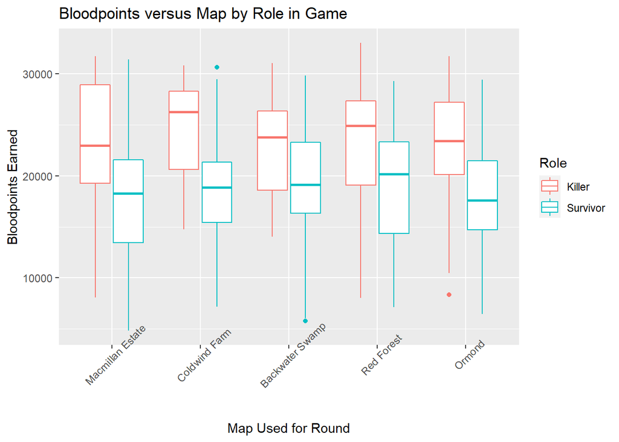

```r
ggplot(data = round1v5) +
  aes(x = map, y = bloodpoints, color = role) +

  geom_boxplot() +

  labs(title = "Bloodpoints versus Map by Role in Game",
       x = "Map Used for Round",
       y = "Bloodpoints Earned", color = "Role") + scale_x_discrete(labels = c("1" = "Macmillan Estate", "2" = "Coldwind Farm", "3" = "Backwater Swamp", "4" = "Red Forest", "5" = "Ormond")) +
  theme(axis.text.x = element_text(angle=45)) +
  scale_color_discrete(labels = c("1" = "Killer", "2" = "Survivor"))
```

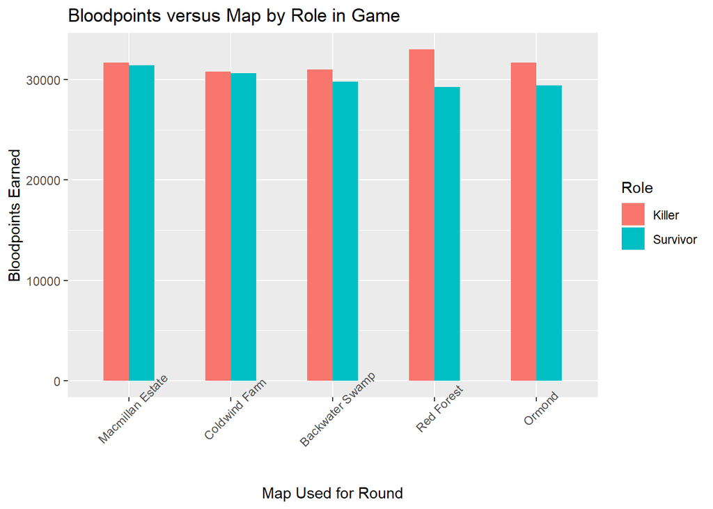

```r
ggplot(data=round1v5, aes(x=map, y=bloodpoints, fill=role)) +
  geom_bar(position ="dodge", stat="identity", width=0.5) +

  labs(title = "Bloodpoints versus Map by Role in Game",
       x = "Map Used for Round",
       y = "Bloodpoints Earned", fill = "Role") + scale_x_discrete(labels = c("1" = "Macmillan Estate", "2" = "Coldwind Farm", "3" = "Backwater Swamp", "4" = "Red Forest", "5" = "Ormond")) +
  theme(axis.text.x = element_text(angle=45)) +
  scale_fill_discrete(labels = c("1" = "Killer", "2" = "Survivor"))
```

## Final Summary (10 points)

> *Summarize your research question and findings below.*

Research Question Recap:Do killers earn significantly more points than survivors in Dead by Daylight (DBD)?

> *Are your findings what you expected? Why or Why not?*